# Risk Factor Analysis

## Outcome Variable

**Outcome Variable:** ever_stunted

## Predictor Variables

**Intervention Variable:** perdiar6

**Adjustment Set:**

- arm
- sex
- W_mage
- meducyrs
- W_mhtcm
- W_mwtkg
- W_mbmi
- W_birthwt
- W_birthlen
- W_nrooms
- month
- brthmon
- impfloor
- impsan
- safeh20
- delta_W_mage
- delta_meducyrs
- delta_W_mhtcm
- delta_W_mwtkg
- delta_W_mbmi
- delta_W_birthwt
- delta_W_birthlen
- delta_W_nrooms
- delta_month
- delta_brthmon
- delta_impfloor
- delta_impsan
- delta_safeh20

## Stratifying Variables

The analysis was stratified on these variable(s):

- agecat
- studyid
- country

## Data Summary

| agecat | studyid | country | perdiar6 | ever_stunted | n_cell | n |
| --- | --- | --- | --- | --- | --- | --- |
| 0-24 months (no birth st.) | ki0047075b-MAL-ED | BANGLADESH | 0% | 0 | 36 | 217 |
| 0-24 months (no birth st.) | ki0047075b-MAL-ED | BANGLADESH | 0% | 1 | 36 | 217 |
| 0-24 months (no birth st.) | ki0047075b-MAL-ED | BANGLADESH | (0%, 5%] | 0 | 41 | 217 |
| 0-24 months (no birth st.) | ki0047075b-MAL-ED | BANGLADESH | (0%, 5%] | 1 | 44 | 217 |
| 0-24 months (no birth st.) | ki0047075b-MAL-ED | BANGLADESH | >5% | 0 | 27 | 217 |
| 0-24 months (no birth st.) | ki0047075b-MAL-ED | BANGLADESH | >5% | 1 | 33 | 217 |
| 0-24 months (no birth st.) | ki0047075b-MAL-ED | BRAZIL | 0% | 0 | 165 | 208 |
| 0-24 months (no birth st.) | ki0047075b-MAL-ED | BRAZIL | 0% | 1 | 27 | 208 |
| 0-24 months (no birth st.) | ki0047075b-MAL-ED | BRAZIL | (0%, 5%] | 0 | 12 | 208 |
| 0-24 months (no birth st.) | ki0047075b-MAL-ED | BRAZIL | (0%, 5%] | 1 | 2 | 208 |
| 0-24 months (no birth st.) | ki0047075b-MAL-ED | BRAZIL | >5% | 0 | 2 | 208 |
| 0-24 months (no birth st.) | ki0047075b-MAL-ED | BRAZIL | >5% | 1 | 0 | 208 |
| 0-24 months (no birth st.) | ki0047075b-MAL-ED | INDIA | 0% | 0 | 24 | 209 |
| 0-24 months (no birth st.) | ki0047075b-MAL-ED | INDIA | 0% | 1 | 25 | 209 |
| 0-24 months (no birth st.) | ki0047075b-MAL-ED | INDIA | (0%, 5%] | 0 | 54 | 209 |
| 0-24 months (no birth st.) | ki0047075b-MAL-ED | INDIA | (0%, 5%] | 1 | 52 | 209 |
| 0-24 months (no birth st.) | ki0047075b-MAL-ED | INDIA | >5% | 0 | 23 | 209 |
| 0-24 months (no birth st.) | ki0047075b-MAL-ED | INDIA | >5% | 1 | 31 | 209 |
| 0-24 months (no birth st.) | ki0047075b-MAL-ED | NEPAL | 0% | 0 | 54 | 212 |
| 0-24 months (no birth st.) | ki0047075b-MAL-ED | NEPAL | 0% | 1 | 20 | 212 |
| 0-24 months (no birth st.) | ki0047075b-MAL-ED | NEPAL | (0%, 5%] | 0 | 54 | 212 |
| 0-24 months (no birth st.) | ki0047075b-MAL-ED | NEPAL | (0%, 5%] | 1 | 14 | 212 |
| 0-24 months (no birth st.) | ki0047075b-MAL-ED | NEPAL | >5% | 0 | 49 | 212 |
| 0-24 months (no birth st.) | ki0047075b-MAL-ED | NEPAL | >5% | 1 | 21 | 212 |
| 0-24 months (no birth st.) | ki0047075b-MAL-ED | PERU | 0% | 0 | 37 | 266 |
| 0-24 months (no birth st.) | ki0047075b-MAL-ED | PERU | 0% | 1 | 40 | 266 |
| 0-24 months (no birth st.) | ki0047075b-MAL-ED | PERU | (0%, 5%] | 0 | 29 | 266 |
| 0-24 months (no birth st.) | ki0047075b-MAL-ED | PERU | (0%, 5%] | 1 | 51 | 266 |
| 0-24 months (no birth st.) | ki0047075b-MAL-ED | PERU | >5% | 0 | 49 | 266 |
| 0-24 months (no birth st.) | ki0047075b-MAL-ED | PERU | >5% | 1 | 60 | 266 |

[output cut: 258 more lines]

The following strata were considered:

- agecat: 0-24 months (no birth st.), studyid: ki0047075b-MAL-ED, country: BANGLADESH
- agecat: 0-24 months (no birth st.), studyid: ki0047075b-MAL-ED, country: BRAZIL
- agecat: 0-24 months (no birth st.), studyid: ki0047075b-MAL-ED, country: INDIA
- agecat: 0-24 months (no birth st.), studyid: ki0047075b-MAL-ED, country: NEPAL
- agecat: 0-24 months (no birth st.), studyid: ki0047075b-MAL-ED, country: PERU
- agecat: 0-24 months (no birth st.), studyid: ki0047075b-MAL-ED, country: SOUTH AFRICA
- agecat: 0-24 months (no birth st.), studyid: ki0047075b-MAL-ED, country: TANZANIA, UNITED REPUBLIC OF
- agecat: 0-24 months (no birth st.), studyid: ki1000109-ResPak, country: PAKISTAN
- agecat: 0-24 months (no birth st.), studyid: ki1017093-NIH-Birth, country: BANGLADESH
- agecat: 0-24 months (no birth st.), studyid: ki1017093b-PROVIDE, country: BANGLADESH
- agecat: 0-24 months (no birth st.), studyid: ki1017093c-NIH-Crypto, country: BANGLADESH
- agecat: 0-24 months (no birth st.), studyid: ki1114097-CMIN, country: BANGLADESH
- agecat: 0-24 months (no birth st.), studyid: ki1114097-CMIN, country: BRAZIL
- agecat: 0-24 months (no birth st.), studyid: ki1114097-CMIN, country: GUINEA-BISSAU
- agecat: 0-24 months (no birth st.), studyid: ki1114097-CMIN, country: PERU
- agecat: 0-24 months (no birth st.), studyid: ki1114097-CONTENT, country: PERU
- agecat: 0-6 months (no birth st.), studyid: ki0047075b-MAL-ED, country: BANGLADESH
- agecat: 0-6 months (no birth st.), studyid: ki0047075b-MAL-ED, country: BRAZIL
- agecat: 0-6 months (no birth st.), studyid: ki0047075b-MAL-ED, country: INDIA
- agecat: 0-6 months (no birth st.), studyid: ki0047075b-MAL-ED, country: NEPAL
- agecat: 0-6 months (no birth st.), studyid: ki0047075b-MAL-ED, country: PERU
- agecat: 0-6 months (no birth st.), studyid: ki0047075b-MAL-ED, country: SOUTH AFRICA
- agecat: 0-6 months (no birth st.), studyid: ki0047075b-MAL-ED, country: TANZANIA, UNITED REPUBLIC OF
- agecat: 0-6 months (no birth st.), studyid: ki1000109-ResPak, country: PAKISTAN
- agecat: 0-6 months (no birth st.), studyid: ki1017093-NIH-Birth, country: BANGLADESH
- agecat: 0-6 months (no birth st.), studyid: ki1017093b-PROVIDE, country: BANGLADESH
- agecat: 0-6 months (no birth st.), studyid: ki1017093c-NIH-Crypto, country: BANGLADESH
- agecat: 0-6 months (no birth st.), studyid: ki1114097-CMIN, country: BANGLADESH
- agecat: 0-6 months (no birth st.), studyid: ki1114097-CMIN, country: BRAZIL
- agecat: 0-6 months (no birth st.), studyid: ki1114097-CMIN, country: GUINEA-BISSAU
- agecat: 0-6 months (no birth st.), studyid: ki1114097-CMIN, country: PERU
- agecat: 0-6 months (no birth st.), studyid: ki1114097-CONTENT, country: PERU
- agecat: 6-24 months, studyid: ki0047075b-MAL-ED, country: BANGLADESH
- agecat: 6-24 months, studyid: ki0047075b-MAL-ED, country: BRAZIL
- agecat: 6-24 months, studyid: ki0047075b-MAL-ED, country: INDIA
- agecat: 6-24 months, studyid: ki0047075b-MAL-ED, country: NEPAL
- agecat: 6-24 months, studyid: ki0047075b-MAL-ED, country: PERU
- agecat: 6-24 months, studyid: ki0047075b-MAL-ED, country: SOUTH AFRICA
- agecat: 6-24 months, studyid: ki0047075b-MAL-ED, country: TANZANIA, UNITED REPUBLIC OF
- agecat: 6-24 months, studyid: ki1000109-ResPak, country: PAKISTAN
- agecat: 6-24 months, studyid: ki1017093-NIH-Birth, country: BANGLADESH
- agecat: 6-24 months, studyid: ki1017093b-PROVIDE, country: BANGLADESH
- agecat: 6-24 months, studyid: ki1017093c-NIH-Crypto, country: BANGLADESH
- agecat: 6-24 months, studyid: ki1114097-CMIN, country: BANGLADESH
- agecat: 6-24 months, studyid: ki1114097-CMIN, country: BRAZIL
- agecat: 6-24 months, studyid: ki1114097-CMIN, country: GUINEA-BISSAU
- agecat: 6-24 months, studyid: ki1114097-CMIN, country: PERU
- agecat: 6-24 months, studyid: ki1114097-CONTENT, country: PERU

### Dropped Strata

Some strata were dropped due to rare outcomes:

- agecat: 0-24 months (no birth st.), studyid: ki0047075b-MAL-ED, country: BRAZIL
- agecat: 0-24 months (no birth st.), studyid: ki0047075b-MAL-ED, country: SOUTH AFRICA
- agecat: 0-6 months (no birth st.), studyid: ki0047075b-MAL-ED, country: BRAZIL
- agecat: 0-6 months (no birth st.), studyid: ki0047075b-MAL-ED, country: NEPAL
- agecat: 0-6 months (no birth st.), studyid: ki0047075b-MAL-ED, country: SOUTH AFRICA
- agecat: 0-6 months (no birth st.), studyid: ki1114097-CMIN, country: BRAZIL
- agecat: 0-6 months (no birth st.), studyid: ki1114097-CMIN, country: GUINEA-BISSAU
- agecat: 0-6 months (no birth st.), studyid: ki1114097-CONTENT, country: PERU
- agecat: 6-24 months, studyid: ki0047075b-MAL-ED, country: BRAZIL
- agecat: 6-24 months, studyid: ki0047075b-MAL-ED, country: SOUTH AFRICA
- agecat: 6-24 months, studyid: ki1000109-ResPak, country: PAKISTAN
- agecat: 6-24 months, studyid: ki1114097-CONTENT, country: PERU

## Methods Detail

We’re interested in the causal parameters $E[Y_a]$ for all values of $a \in \mathcal{A}$. These parameters represent the mean outcome if, possibly contrary to fact, we intervened to set all units to have $A=a$. Under the randomization and positivity assumptions, these are identified by the statistical parameters $\psi_a=E_W[E_{Y|A,W}(Y|A=a,W)]$. In addition, we’re interested in the mean of $Y$, $E[Y]$ under no intervention (the observed mean). We will estimate these parameters by using SuperLearner to fit the relevant likelihood factors – $E_{Y|A,W}(Y|A=a,W)$ and $p(A=a|W)$, and then updating our likelihood fit using a joint TMLE.

For unadjusted analyses ($W=\{\}$), initial likelihoods were estimated using Lrnr_glm to estimate the simple $E(Y|A)$ and Lrnr_mean to estimate $p(A)$. For adjusted analyses, a small library containing Lrnr_glmnet, Lrnr_xgboost, and Lrnr_mean was used.

Having estimated these parameters, we will then use the delta method to estimate relative risks and attributable risks relative to a prespecified baseline level of $A$.

# Results Detail

## Results Plots

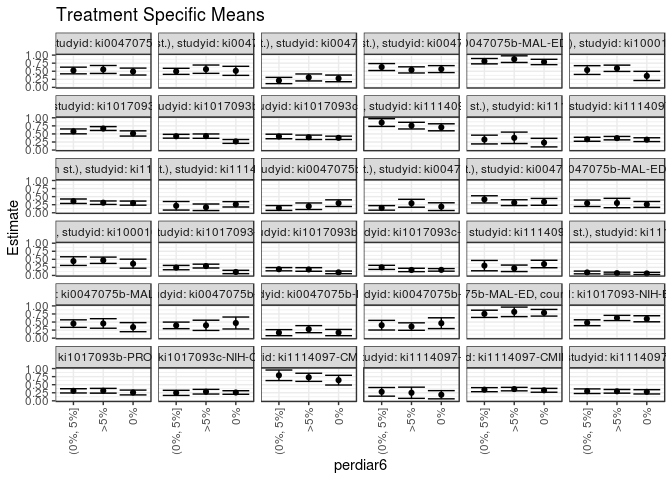

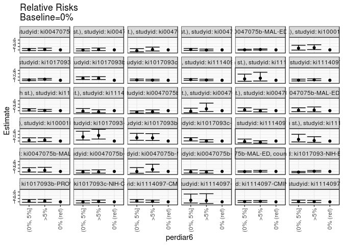

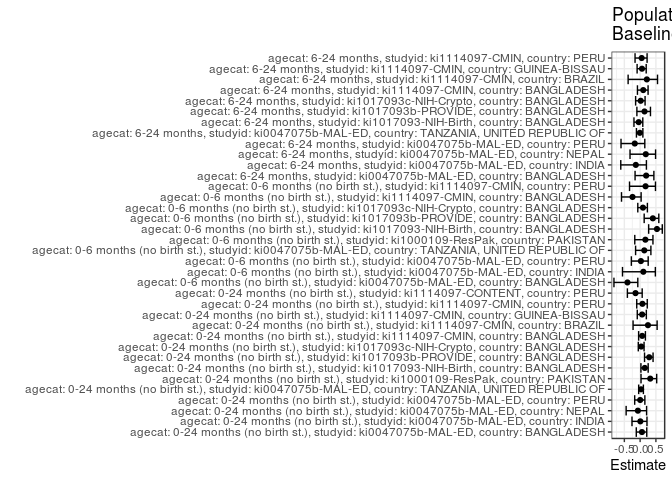

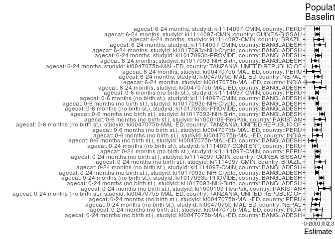

## Results Table

### Parameter: TSM

| agecat | studyid | country | intervention_level | baseline_level | estimate | ci_lower | ci_upper |
| --- | --- | --- | --- | --- | --- | --- | --- |
| 0-24 months (no birth st.) | ki0047075b-MAL-ED | BANGLADESH | 0% | NA | 0.4902051 | 0.3828125 | 0.5975978 |
| 0-24 months (no birth st.) | ki0047075b-MAL-ED | BANGLADESH | (0%, 5%] | NA | 0.5232495 | 0.4197415 | 0.6267576 |
| 0-24 months (no birth st.) | ki0047075b-MAL-ED | BANGLADESH | >5% | NA | 0.5544801 | 0.4309641 | 0.6779961 |
| 0-24 months (no birth st.) | ki0047075b-MAL-ED | INDIA | 0% | NA | 0.5128470 | 0.3723592 | 0.6533348 |
| 0-24 months (no birth st.) | ki0047075b-MAL-ED | INDIA | (0%, 5%] | NA | 0.4964608 | 0.4023444 | 0.5905772 |
| 0-24 months (no birth st.) | ki0047075b-MAL-ED | INDIA | >5% | NA | 0.5626676 | 0.4334621 | 0.6918731 |
| 0-24 months (no birth st.) | ki0047075b-MAL-ED | NEPAL | 0% | NA | 0.2779045 | 0.1746492 | 0.3811598 |
| 0-24 months (no birth st.) | ki0047075b-MAL-ED | NEPAL | (0%, 5%] | NA | 0.2125281 | 0.1153679 | 0.3096884 |
| 0-24 months (no birth st.) | ki0047075b-MAL-ED | NEPAL | >5% | NA | 0.3074360 | 0.1990602 | 0.4158117 |
| 0-24 months (no birth st.) | ki0047075b-MAL-ED | PERU | 0% | NA | 0.5666419 | 0.4590382 | 0.6742456 |
| 0-24 months (no birth st.) | ki0047075b-MAL-ED | PERU | (0%, 5%] | NA | 0.6302812 | 0.5221587 | 0.7384038 |
| 0-24 months (no birth st.) | ki0047075b-MAL-ED | PERU | >5% | NA | 0.5417172 | 0.4465052 | 0.6369292 |
| 0-24 months (no birth st.) | ki0047075b-MAL-ED | TANZANIA, UNITED REPUBLIC OF | 0% | NA | 0.7872340 | 0.7043099 | 0.8701582 |
| 0-24 months (no birth st.) | ki0047075b-MAL-ED | TANZANIA, UNITED REPUBLIC OF | (0%, 5%] | NA | 0.8117647 | 0.7284737 | 0.8950557 |
| 0-24 months (no birth st.) | ki0047075b-MAL-ED | TANZANIA, UNITED REPUBLIC OF | >5% | NA | 0.8750000 | 0.7722762 | 0.9777238 |
| 0-24 months (no birth st.) | ki1000109-ResPak | PAKISTAN | 0% | NA | 0.3549093 | 0.2131880 | 0.4966306 |
| 0-24 months (no birth st.) | ki1000109-ResPak | PAKISTAN | (0%, 5%] | NA | 0.5368317 | 0.4006412 | 0.6730222 |
| 0-24 months (no birth st.) | ki1000109-ResPak | PAKISTAN | >5% | NA | 0.5913649 | 0.4933274 | 0.6894025 |
| 0-24 months (no birth st.) | ki1017093-NIH-Birth | BANGLADESH | 0% | NA | 0.5149215 | 0.4335084 | 0.5963347 |
| 0-24 months (no birth st.) | ki1017093-NIH-Birth | BANGLADESH | (0%, 5%] | NA | 0.5786506 | 0.5032136 | 0.6540876 |
| 0-24 months (no birth st.) | ki1017093-NIH-Birth | BANGLADESH | >5% | NA | 0.6673866 | 0.6071140 | 0.7276592 |
| 0-24 months (no birth st.) | ki1017093b-PROVIDE | BANGLADESH | 0% | NA | 0.2674398 | 0.2078020 | 0.3270777 |
| 0-24 months (no birth st.) | ki1017093b-PROVIDE | BANGLADESH | (0%, 5%] | NA | 0.4280213 | 0.3685349 | 0.4875077 |
| 0-24 months (no birth st.) | ki1017093b-PROVIDE | BANGLADESH | >5% | NA | 0.4312355 | 0.3641061 | 0.4983649 |
| 0-24 months (no birth st.) | ki1017093c-NIH-Crypto | BANGLADESH | 0% | NA | 0.3787778 | 0.3270876 | 0.4304679 |
| 0-24 months (no birth st.) | ki1017093c-NIH-Crypto | BANGLADESH | (0%, 5%] | NA | 0.4214366 | 0.3509310 | 0.4919422 |
| 0-24 months (no birth st.) | ki1017093c-NIH-Crypto | BANGLADESH | >5% | NA | 0.3961109 | 0.3278957 | 0.4643262 |
| 0-24 months (no birth st.) | ki1114097-CMIN | BANGLADESH | 0% | NA | 0.7058824 | 0.5972606 | 0.8145041 |
| 0-24 months (no birth st.) | ki1114097-CMIN | BANGLADESH | (0%, 5%] | NA | 0.8529412 | 0.7335396 | 0.9723428 |
| 0-24 months (no birth st.) | ki1114097-CMIN | BANGLADESH | >5% | NA | 0.7575758 | 0.6538770 | 0.8612745 |

[output cut: 78 more lines]

### Parameter: E(Y)

| agecat | studyid | country | intervention_level | baseline_level | estimate | ci_lower | ci_upper |
| --- | --- | --- | --- | --- | --- | --- | --- |
| 0-24 months (no birth st.) | ki0047075b-MAL-ED | BANGLADESH | NA | NA | 0.5207373 | 0.4541154 | 0.5873593 |
| 0-24 months (no birth st.) | ki0047075b-MAL-ED | INDIA | NA | NA | 0.5167464 | 0.4488350 | 0.5846578 |
| 0-24 months (no birth st.) | ki0047075b-MAL-ED | NEPAL | NA | NA | 0.2594340 | 0.2002911 | 0.3185768 |
| 0-24 months (no birth st.) | ki0047075b-MAL-ED | PERU | NA | NA | 0.5676692 | 0.5080232 | 0.6273151 |
| 0-24 months (no birth st.) | ki0047075b-MAL-ED | TANZANIA, UNITED REPUBLIC OF | NA | NA | 0.8127854 | 0.7610035 | 0.8645672 |
| 0-24 months (no birth st.) | ki1000109-ResPak | PAKISTAN | NA | NA | 0.5223881 | 0.4531624 | 0.5916138 |
| 0-24 months (no birth st.) | ki1017093-NIH-Birth | BANGLADESH | NA | NA | 0.6041667 | 0.5624147 | 0.6459187 |
| 0-24 months (no birth st.) | ki1017093b-PROVIDE | BANGLADESH | NA | NA | 0.3753943 | 0.3376725 | 0.4131162 |
| 0-24 months (no birth st.) | ki1017093c-NIH-Crypto | BANGLADESH | NA | NA | 0.3935681 | 0.3560687 | 0.4310676 |
| 0-24 months (no birth st.) | ki1114097-CMIN | BANGLADESH | NA | NA | 0.7559524 | 0.6908084 | 0.8210964 |
| 0-24 months (no birth st.) | ki1114097-CMIN | BRAZIL | NA | NA | 0.3070175 | 0.2219720 | 0.3920631 |
| 0-24 months (no birth st.) | ki1114097-CMIN | GUINEA-BISSAU | NA | NA | 0.3443038 | 0.3111501 | 0.3774575 |
| 0-24 months (no birth st.) | ki1114097-CMIN | PERU | NA | NA | 0.3229167 | 0.2875370 | 0.3582963 |
| 0-24 months (no birth st.) | ki1114097-CONTENT | PERU | NA | NA | 0.2284264 | 0.1696529 | 0.2871999 |
| 0-6 months (no birth st.) | ki0047075b-MAL-ED | BANGLADESH | NA | NA | 0.2119816 | 0.1574763 | 0.2664868 |
| 0-6 months (no birth st.) | ki0047075b-MAL-ED | INDIA | NA | NA | 0.2105263 | 0.1551227 | 0.2659300 |
| 0-6 months (no birth st.) | ki0047075b-MAL-ED | PERU | NA | NA | 0.3458647 | 0.2885967 | 0.4031327 |
| 0-6 months (no birth st.) | ki0047075b-MAL-ED | TANZANIA, UNITED REPUBLIC OF | NA | NA | 0.2968037 | 0.2361590 | 0.3574483 |
| 0-6 months (no birth st.) | ki1000109-ResPak | PAKISTAN | NA | NA | 0.4378109 | 0.3690538 | 0.5065681 |
| 0-6 months (no birth st.) | ki1017093-NIH-Birth | BANGLADESH | NA | NA | 0.2291667 | 0.1932828 | 0.2650505 |
| 0-6 months (no birth st.) | ki1017093b-PROVIDE | BANGLADESH | NA | NA | 0.1593060 | 0.1307970 | 0.1878150 |
| 0-6 months (no birth st.) | ki1017093c-NIH-Crypto | BANGLADESH | NA | NA | 0.1898928 | 0.1597870 | 0.2199986 |
| 0-6 months (no birth st.) | ki1114097-CMIN | BANGLADESH | NA | NA | 0.2857143 | 0.2171983 | 0.3542303 |
| 0-6 months (no birth st.) | ki1114097-CMIN | PERU | NA | NA | 0.0744681 | 0.0543935 | 0.0945427 |
| 6-24 months | ki0047075b-MAL-ED | BANGLADESH | NA | NA | 0.4213836 | 0.3443902 | 0.4983771 |
| 6-24 months | ki0047075b-MAL-ED | INDIA | NA | NA | 0.4129032 | 0.3351414 | 0.4906651 |
| 6-24 months | ki0047075b-MAL-ED | NEPAL | NA | NA | 0.2102564 | 0.1529155 | 0.2675974 |
| 6-24 months | ki0047075b-MAL-ED | PERU | NA | NA | 0.3959732 | 0.3171819 | 0.4747644 |
| 6-24 months | ki0047075b-MAL-ED | TANZANIA, UNITED REPUBLIC OF | NA | NA | 0.7793103 | 0.7115754 | 0.8470453 |
| 6-24 months | ki1017093-NIH-Birth | BANGLADESH | NA | NA | 0.5739130 | 0.5216565 | 0.6261696 |
| 6-24 months | ki1017093b-PROVIDE | BANGLADESH | NA | NA | 0.2997812 | 0.2577294 | 0.3418330 |
| 6-24 months | ki1017093c-NIH-Crypto | BANGLADESH | NA | NA | 0.2628458 | 0.2244546 | 0.3012371 |
| 6-24 months | ki1114097-CMIN | BANGLADESH | NA | NA | 0.7117117 | 0.6270636 | 0.7963598 |
| 6-24 months | ki1114097-CMIN | BRAZIL | NA | NA | 0.2403846 | 0.1578607 | 0.3229085 |
| 6-24 months | ki1114097-CMIN | GUINEA-BISSAU | NA | NA | 0.3467532 | 0.3131150 | 0.3803915 |
| 6-24 months | ki1114097-CMIN | PERU | NA | NA | 0.2940171 | 0.2570662 | 0.3309680 |

### Parameter: RR

| agecat | studyid | country | intervention_level | baseline_level | estimate | ci_lower | ci_upper |
| --- | --- | --- | --- | --- | --- | --- | --- |
| 0-24 months (no birth st.) | ki0047075b-MAL-ED | BANGLADESH | 0% | 0% | 1.0000000 | 1.0000000 | 1.0000000 |
| 0-24 months (no birth st.) | ki0047075b-MAL-ED | BANGLADESH | (0%, 5%] | 0% | 1.0674094 | 0.8034933 | 1.4180115 |
| 0-24 months (no birth st.) | ki0047075b-MAL-ED | BANGLADESH | >5% | 0% | 1.1311186 | 0.8351379 | 1.5319978 |
| 0-24 months (no birth st.) | ki0047075b-MAL-ED | INDIA | 0% | 0% | 1.0000000 | 1.0000000 | 1.0000000 |
| 0-24 months (no birth st.) | ki0047075b-MAL-ED | INDIA | (0%, 5%] | 0% | 0.9680486 | 0.6975436 | 1.3434546 |
| 0-24 months (no birth st.) | ki0047075b-MAL-ED | INDIA | >5% | 0% | 1.0971452 | 0.7707804 | 1.5616997 |
| 0-24 months (no birth st.) | ki0047075b-MAL-ED | NEPAL | 0% | 0% | 1.0000000 | 1.0000000 | 1.0000000 |
| 0-24 months (no birth st.) | ki0047075b-MAL-ED | NEPAL | (0%, 5%] | 0% | 0.7647525 | 0.4234084 | 1.3812821 |
| 0-24 months (no birth st.) | ki0047075b-MAL-ED | NEPAL | >5% | 0% | 1.1062649 | 0.6632083 | 1.8453057 |
| 0-24 months (no birth st.) | ki0047075b-MAL-ED | PERU | 0% | 0% | 1.0000000 | 1.0000000 | 1.0000000 |
| 0-24 months (no birth st.) | ki0047075b-MAL-ED | PERU | (0%, 5%] | 0% | 1.1123096 | 0.8599500 | 1.4387263 |
| 0-24 months (no birth st.) | ki0047075b-MAL-ED | PERU | >5% | 0% | 0.9560133 | 0.7395372 | 1.2358560 |
| 0-24 months (no birth st.) | ki0047075b-MAL-ED | TANZANIA, UNITED REPUBLIC OF | 0% | 0% | 1.0000000 | 1.0000000 | 1.0000000 |
| 0-24 months (no birth st.) | ki0047075b-MAL-ED | TANZANIA, UNITED REPUBLIC OF | (0%, 5%] | 0% | 1.0311606 | 0.8901510 | 1.1945076 |
| 0-24 months (no birth st.) | ki0047075b-MAL-ED | TANZANIA, UNITED REPUBLIC OF | >5% | 0% | 1.1114865 | 0.9493007 | 1.3013814 |
| 0-24 months (no birth st.) | ki1000109-ResPak | PAKISTAN | 0% | 0% | 1.0000000 | 1.0000000 | 1.0000000 |
| 0-24 months (no birth st.) | ki1000109-ResPak | PAKISTAN | (0%, 5%] | 0% | 1.5125885 | 0.9428917 | 2.4264970 |
| 0-24 months (no birth st.) | ki1000109-ResPak | PAKISTAN | >5% | 0% | 1.6662425 | 1.0805770 | 2.5693346 |
| 0-24 months (no birth st.) | ki1017093-NIH-Birth | BANGLADESH | 0% | 0% | 1.0000000 | 1.0000000 | 1.0000000 |
| 0-24 months (no birth st.) | ki1017093-NIH-Birth | BANGLADESH | (0%, 5%] | 0% | 1.1237646 | 0.9185597 | 1.3748118 |
| 0-24 months (no birth st.) | ki1017093-NIH-Birth | BANGLADESH | >5% | 0% | 1.2960937 | 1.0818876 | 1.5527112 |
| 0-24 months (no birth st.) | ki1017093b-PROVIDE | BANGLADESH | 0% | 0% | 1.0000000 | 1.0000000 | 1.0000000 |
| 0-24 months (no birth st.) | ki1017093b-PROVIDE | BANGLADESH | (0%, 5%] | 0% | 1.6004397 | 1.2391019 | 2.0671482 |
| 0-24 months (no birth st.) | ki1017093b-PROVIDE | BANGLADESH | >5% | 0% | 1.6124580 | 1.2354606 | 2.1044952 |
| 0-24 months (no birth st.) | ki1017093c-NIH-Crypto | BANGLADESH | 0% | 0% | 1.0000000 | 1.0000000 | 1.0000000 |
| 0-24 months (no birth st.) | ki1017093c-NIH-Crypto | BANGLADESH | (0%, 5%] | 0% | 1.1126223 | 0.9044522 | 1.3687052 |
| 0-24 months (no birth st.) | ki1017093c-NIH-Crypto | BANGLADESH | >5% | 0% | 1.0457607 | 0.8438762 | 1.2959430 |
| 0-24 months (no birth st.) | ki1114097-CMIN | BANGLADESH | 0% | 0% | 1.0000000 | 1.0000000 | 1.0000000 |
| 0-24 months (no birth st.) | ki1114097-CMIN | BANGLADESH | (0%, 5%] | 0% | 1.2083333 | 0.9813886 | 1.4877587 |
| 0-24 months (no birth st.) | ki1114097-CMIN | BANGLADESH | >5% | 0% | 1.0732323 | 0.8734742 | 1.3186739 |

[output cut: 78 more lines]

### Parameter: PAR

| agecat | studyid | country | intervention_level | baseline_level | estimate | ci_lower | ci_upper |
| --- | --- | --- | --- | --- | --- | --- | --- |
| 0-24 months (no birth st.) | ki0047075b-MAL-ED | BANGLADESH | 0% | NA | 0.0305322 | -0.0554419 | 0.1165063 |
| 0-24 months (no birth st.) | ki0047075b-MAL-ED | INDIA | 0% | NA | 0.0038994 | -0.1175396 | 0.1253384 |
| 0-24 months (no birth st.) | ki0047075b-MAL-ED | NEPAL | 0% | NA | -0.0184705 | -0.1013442 | 0.0644032 |
| 0-24 months (no birth st.) | ki0047075b-MAL-ED | PERU | 0% | NA | 0.0010273 | -0.0901077 | 0.0921623 |
| 0-24 months (no birth st.) | ki0047075b-MAL-ED | TANZANIA, UNITED REPUBLIC OF | 0% | NA | 0.0255513 | -0.0349031 | 0.0860057 |
| 0-24 months (no birth st.) | ki1000109-ResPak | PAKISTAN | 0% | NA | 0.1674788 | 0.0417683 | 0.2931892 |
| 0-24 months (no birth st.) | ki1017093-NIH-Birth | BANGLADESH | 0% | NA | 0.0892451 | 0.0206280 | 0.1578623 |
| 0-24 months (no birth st.) | ki1017093b-PROVIDE | BANGLADESH | 0% | NA | 0.1079545 | 0.0576479 | 0.1582611 |
| 0-24 months (no birth st.) | ki1017093c-NIH-Crypto | BANGLADESH | 0% | NA | 0.0147904 | -0.0211396 | 0.0507204 |
| 0-24 months (no birth st.) | ki1114097-CMIN | BANGLADESH | 0% | NA | 0.0500700 | -0.0304974 | 0.1306374 |
| 0-24 months (no birth st.) | ki1114097-CMIN | BRAZIL | 0% | NA | 0.0762483 | -0.0369029 | 0.1893995 |
| 0-24 months (no birth st.) | ki1114097-CMIN | GUINEA-BISSAU | 0% | NA | 0.0220188 | -0.0272254 | 0.0712630 |
| 0-24 months (no birth st.) | ki1114097-CMIN | PERU | 0% | NA | 0.0238720 | -0.0296129 | 0.0773570 |
| 0-24 months (no birth st.) | ki1114097-CONTENT | PERU | 0% | NA | -0.0332558 | -0.0866666 | 0.0201549 |
| 0-6 months (no birth st.) | ki0047075b-MAL-ED | BANGLADESH | 0% | NA | -0.0850922 | -0.1645669 | -0.0056175 |
| 0-6 months (no birth st.) | ki0047075b-MAL-ED | INDIA | 0% | NA | 0.0215669 | -0.0823567 | 0.1254904 |
| 0-6 months (no birth st.) | ki0047075b-MAL-ED | PERU | 0% | NA | 0.0084738 | -0.0826953 | 0.0996429 |
| 0-6 months (no birth st.) | ki0047075b-MAL-ED | TANZANIA, UNITED REPUBLIC OF | 0% | NA | 0.0391871 | -0.0316849 | 0.1100592 |
| 0-6 months (no birth st.) | ki1000109-ResPak | PAKISTAN | 0% | NA | 0.0730291 | -0.0504617 | 0.1965199 |
| 0-6 months (no birth st.) | ki1017093-NIH-Birth | BANGLADESH | 0% | NA | 0.1222972 | 0.0718115 | 0.1727829 |
| 0-6 months (no birth st.) | ki1017093b-PROVIDE | BANGLADESH | 0% | NA | 0.0642947 | 0.0268249 | 0.1017644 |
| 0-6 months (no birth st.) | ki1017093c-NIH-Crypto | BANGLADESH | 0% | NA | 0.0171838 | -0.0115953 | 0.0459629 |
| 0-6 months (no birth st.) | ki1114097-CMIN | BANGLADESH | 0% | NA | -0.0688428 | -0.1565917 | 0.0189060 |
| 0-6 months (no birth st.) | ki1114097-CMIN | PERU | 0% | NA | 0.0128139 | -0.0168521 | 0.0424799 |
| 6-24 months | ki0047075b-MAL-ED | BANGLADESH | 0% | NA | 0.0803704 | -0.0425066 | 0.2032474 |
| 6-24 months | ki0047075b-MAL-ED | INDIA | 0% | NA | -0.0564198 | -0.2208442 | 0.1080046 |
| 6-24 months | ki0047075b-MAL-ED | NEPAL | 0% | NA | 0.0376996 | -0.0444412 | 0.1198404 |
| 6-24 months | ki0047075b-MAL-ED | PERU | 0% | NA | -0.0671058 | -0.2134779 | 0.0792662 |
| 6-24 months | ki0047075b-MAL-ED | TANZANIA, UNITED REPUBLIC OF | 0% | NA | -0.0075749 | -0.0867885 | 0.0716387 |
| 6-24 months | ki1017093-NIH-Birth | BANGLADESH | 0% | NA | -0.0265119 | -0.1064913 | 0.0534675 |
| 6-24 months | ki1017093b-PROVIDE | BANGLADESH | 0% | NA | 0.0416407 | -0.0221835 | 0.1054649 |
| 6-24 months | ki1017093c-NIH-Crypto | BANGLADESH | 0% | NA | 0.0048526 | -0.0343629 | 0.0440681 |
| 6-24 months | ki1114097-CMIN | BANGLADESH | 0% | NA | 0.0706861 | -0.0474877 | 0.1888598 |
| 6-24 months | ki1114097-CMIN | BRAZIL | 0% | NA | 0.0511954 | -0.0558040 | 0.1581948 |
| 6-24 months | ki1114097-CMIN | GUINEA-BISSAU | 0% | NA | 0.0205882 | -0.0290909 | 0.0702673 |
| 6-24 months | ki1114097-CMIN | PERU | 0% | NA | 0.0143113 | -0.0413678 | 0.0699904 |

### Parameter: PAF

| agecat | studyid | country | intervention_level | baseline_level | estimate | ci_lower | ci_upper |
| --- | --- | --- | --- | --- | --- | --- | --- |
| 0-24 months (no birth st.) | ki0047075b-MAL-ED | BANGLADESH | 0% | NA | 0.0586326 | -0.1218024 | 0.2100458 |
| 0-24 months (no birth st.) | ki0047075b-MAL-ED | INDIA | 0% | NA | 0.0075461 | -0.2576489 | 0.2168206 |
| 0-24 months (no birth st.) | ki0047075b-MAL-ED | NEPAL | 0% | NA | -0.0711954 | -0.4432714 | 0.2049592 |
| 0-24 months (no birth st.) | ki0047075b-MAL-ED | PERU | 0% | NA | 0.0018097 | -0.1723582 | 0.1501028 |
| 0-24 months (no birth st.) | ki0047075b-MAL-ED | TANZANIA, UNITED REPUBLIC OF | 0% | NA | 0.0314368 | -0.0460885 | 0.1032166 |
| 0-24 months (no birth st.) | ki1000109-ResPak | PAKISTAN | 0% | NA | 0.3206022 | 0.0282694 | 0.5249904 |
| 0-24 months (no birth st.) | ki1017093-NIH-Birth | BANGLADESH | 0% | NA | 0.1477161 | 0.0253470 | 0.2547216 |
| 0-24 months (no birth st.) | ki1017093b-PROVIDE | BANGLADESH | 0% | NA | 0.2875763 | 0.1400215 | 0.4098137 |
| 0-24 months (no birth st.) | ki1017093c-NIH-Crypto | BANGLADESH | 0% | NA | 0.0375802 | -0.0582232 | 0.1247102 |
| 0-24 months (no birth st.) | ki1114097-CMIN | BANGLADESH | 0% | NA | 0.0662344 | -0.0474806 | 0.1676044 |
| 0-24 months (no birth st.) | ki1114097-CMIN | BRAZIL | 0% | NA | 0.2483516 | -0.2238161 | 0.5383495 |
| 0-24 months (no birth st.) | ki1114097-CMIN | GUINEA-BISSAU | 0% | NA | 0.0639517 | -0.0905868 | 0.1965917 |
| 0-24 months (no birth st.) | ki1114097-CMIN | PERU | 0% | NA | 0.0739262 | -0.1074555 | 0.2256008 |
| 0-24 months (no birth st.) | ki1114097-CONTENT | PERU | 0% | NA | -0.1455867 | -0.4037931 | 0.0651266 |
| 0-6 months (no birth st.) | ki0047075b-MAL-ED | BANGLADESH | 0% | NA | -0.4014132 | -0.8294271 | -0.0735377 |
| 0-6 months (no birth st.) | ki0047075b-MAL-ED | INDIA | 0% | NA | 0.1024426 | -0.5585310 | 0.4830970 |
| 0-6 months (no birth st.) | ki0047075b-MAL-ED | PERU | 0% | NA | 0.0245004 | -0.2780348 | 0.2554198 |
| 0-6 months (no birth st.) | ki0047075b-MAL-ED | TANZANIA, UNITED REPUBLIC OF | 0% | NA | 0.1320305 | -0.1435415 | 0.3411949 |
| 0-6 months (no birth st.) | ki1000109-ResPak | PAKISTAN | 0% | NA | 0.1668051 | -0.1695456 | 0.4064243 |
| 0-6 months (no birth st.) | ki1017093-NIH-Birth | BANGLADESH | 0% | NA | 0.5336605 | 0.2702906 | 0.7019738 |
| 0-6 months (no birth st.) | ki1017093b-PROVIDE | BANGLADESH | 0% | NA | 0.4035922 | 0.1283387 | 0.5919260 |
| 0-6 months (no birth st.) | ki1017093c-NIH-Crypto | BANGLADESH | 0% | NA | 0.0904921 | -0.0740390 | 0.2298187 |
| 0-6 months (no birth st.) | ki1114097-CMIN | BANGLADESH | 0% | NA | -0.2409499 | -0.5900658 | 0.0315139 |
| 0-6 months (no birth st.) | ki1114097-CMIN | PERU | 0% | NA | 0.1720723 | -0.3358718 | 0.4868787 |
| 6-24 months | ki0047075b-MAL-ED | BANGLADESH | 0% | NA | 0.1907298 | -0.1603303 | 0.4355760 |
| 6-24 months | ki0047075b-MAL-ED | INDIA | 0% | NA | -0.1366417 | -0.6132836 | 0.1991772 |
| 6-24 months | ki0047075b-MAL-ED | NEPAL | 0% | NA | 0.1793029 | -0.3200791 | 0.4897702 |
| 6-24 months | ki0047075b-MAL-ED | PERU | 0% | NA | -0.1694707 | -0.6054153 | 0.1480948 |
| 6-24 months | ki0047075b-MAL-ED | TANZANIA, UNITED REPUBLIC OF | 0% | NA | -0.0097200 | -0.1166819 | 0.0869965 |
| 6-24 months | ki1017093-NIH-Birth | BANGLADESH | 0% | NA | -0.0461949 | -0.1954998 | 0.0844634 |
| 6-24 months | ki1017093b-PROVIDE | BANGLADESH | 0% | NA | 0.1389037 | -0.1026160 | 0.3275204 |
| 6-24 months | ki1017093c-NIH-Crypto | BANGLADESH | 0% | NA | 0.0184618 | -0.1427046 | 0.1568974 |
| 6-24 months | ki1114097-CMIN | BANGLADESH | 0% | NA | 0.0993184 | -0.0847491 | 0.2521521 |
| 6-24 months | ki1114097-CMIN | BRAZIL | 0% | NA | 0.2129730 | -0.3802068 | 0.5512183 |
| 6-24 months | ki1114097-CMIN | GUINEA-BISSAU | 0% | NA | 0.0593742 | -0.0954068 | 0.1922847 |
| 6-24 months | ki1114097-CMIN | PERU | 0% | NA | 0.0486752 | -0.1608675 | 0.2203943 |